# R Notebook

Wraps the ‘CRFsuite’ library https://github.com/chokkan/crfsuite allowing users to fit a Conditional Random Field model and to apply it on existing data. The focus of the implementation is in the area of Natural Language Processing where this R package allows you to easily build and apply models for named entity recognition, text chunking, part of speech tagging, intent recognition or classification of any category you have in mind. Next to training, a small web application is included in the package to allow you to easily construct training data.

```r
devtools::install_github("bnosac/crfsuite", build_vignettes = TRUE)
```

```r
library(crfsuite)
vignette("crfsuite-nlp", package = "crfsuite")
```

```
vignette ‘crfsuite-nlp’ not found
```

```r
# x <- ner_download_modeldata("wikiner-en-wp2")
# table(x1$label)
# x1 %>% filter(label %in% c("I-ORG")) %>% sample_n(size = 10)
# x1 %>% filter(label %in% c("I-LOC")) %>% sample_n(size = 10)
# x1 %>% filter(label %in% c("B-ORG")) %>% sample_n(size = 10)
# x1 %>% filter(label %in% c("B-LOC")) %>% sample_n(size = 10)
# x1 %>% filter(label %in% c("B-MISC")) %>% sample_n(size = 10)
#
# x1 %>% filter(pos %in% c("NNP")) %>% head()
#
# head(x1$token)
# head(x1$label)
# table(x1$pos)
data("airbnb")
data("airbnb_chunks")
```

```r
## More detailed example where text data was annotated with the webapp in the package
## This data is joined with a tokenised dataset to construct the training data which
## is further enriched with attributes of upos/lemma in the neighbourhood
##
library(udpipe)

#you need a model that can do POS tagging, sentence breaking etc. I am using a dutch model for sentence breaking and pos because the data is in dutch. I will test airbnb data in the next example.

udmodel <- udpipe_download_model("dutch-lassysmall")
udmodel <- udpipe_load_model(udmodel$file_model)

#to train the model you need unique text with doc_id. Use the annotated file to get these
airbnb_tokens <- unique(airbnb_chunks[, c("doc_id", "text")])

airbnb_tokens <- udpipe_annotate(udmodel,
                                      x = airbnb_tokens$text,
                                      doc_id = airbnb_tokens$doc_id)
class(airbnb_tokens)


airbnb_tokens <- as.data.frame(airbnb_tokens)

x <- merge(airbnb_chunks, airbnb_tokens)

x <- crf_cbind_attributes(x, terms = c("upos", "lemma"), by = "doc_id")

model <- crf(y = x$chunk_entity,
              x = x[, grep("upos|lemma", colnames(x), value = TRUE)],
              group = x$doc_id,
              method = "lbfgs", options = list(max_iterations = 5))


stats <- summary(model)
stats

plot(stats$iterations$loss, type = "b", xlab = "Iteration", ylab = "Loss")

scores <- predict(model,
                  newdata = x[, grep("upos|lemma", colnames(x))],
                  group = x$doc_id)
head(scores)

## cleanup for CRAN
file.remove(udmodel$file)
## End(Not run)
file.remove(model$file_model)
file.remove("modeldetails.txt")
```

[output not shown]

## Original Example

```r
str(verbatim_tokens)
```

```
'data.frame':   44882 obs. of  17 variables:
 $ doc_id       : chr  "1" "1" "1" "1" ...
 $ paragraph_id : int  1 1 1 1 1 1 1 1 1 1 ...
 $ sentence_id  : int  1 1 1 1 1 1 1 1 1 1 ...
 $ sentence     : chr  "The process was good I need to see how good the rest of the service is" "The process was good I need to see how good the rest of the service is" "The process was good I need to see how good the rest of the service is" "The process was good I need to see how good the rest of t…
 $ start        : int  1 5 13 17 22 24 29 32 36 40 ...
 $ end          : int  3 11 15 20 22 27 30 34 38 43 ...
 $ term_id      : int  1 2 3 4 5 6 7 8 9 10 ...
 $ token_id     : chr  "1" "2" "3" "4" ...
 $ token        : chr  "The" "process" "was" "good" ...
 $ lemma        : chr  "the" "process" "be" "good" ...
 $ upos         : chr  "DET" "NOUN" "AUX" "ADJ" ...
 $ xpos         : chr  "DT" "NN" "VBD" "JJ" ...
 $ feats        : chr  "Definite=Def|PronType=Art" "Number=Sing" "Mood=Ind|Number=Sing|Person=3|Tense=Past|VerbForm=Fin" "Degree=Pos" ...
 $ head_token_id: chr  "2" "4" "4" "0" ...
 $ dep_rel      : chr  "det" "nsubj" "cop" "root" ...
 $ deps         : chr  NA NA NA NA ...
 $ misc         : chr  NA NA NA NA ...
```

```r
x1 %>% filter(upos %in% c("NOUN"))
```

| doc_id | paragraph_id | sentence_id | sentence | start | end | term_id | token_id | token | lemma | upos | xpos | feats | head_token_id | dep_rel | deps | misc | chunk_entity | chunk_id | upos[t-2] | upos[t-1] | upos[t] | upos[t+1] | upos[t+2] | upos[t-2]-upos[t-1] | upos[t-2]-upos[t] | upos[t-2]-upos[t+1] | upos[t-2]-upos[t+2] | upos[t-1]-upos[t] | upos[t-1]-upos[t+1] | … |
| --- | --- | --- | --- | --- | --- | --- | --- | --- | --- | --- | --- | --- | --- | --- | --- | --- | --- | --- | --- | --- | --- | --- | --- | --- | --- | --- | --- | --- | --- | --- |
| 1 | 1 | 1 | The process was good I need to see how good the rest of the service is | 5 | 11 | 2 | 2 | process | process | NOUN | NN | Number=Sing | 4 | nsubj | NA | NA | B-PROCESS | 1 | NA | upos[t-1]=DET | upos[t]=NOUN | upos[t+1]=AUX | upos[t+2]=ADJ | NA | NA | NA | NA | upos[t-1]-upos[t]=DET-NOUN | upos[t-1]-upos[t+1]=DET-AUX | … |
| 1 | 1 | 1 | The process was good I need to see how good the rest of the service is | 49 | 52 | 12 | 12 | rest | rest | NOUN | NN | Number=Sing | 10 | nsubj | NA | NA | O | NA | upos[t-2]=ADJ | upos[t-1]=DET | upos[t]=NOUN | upos[t+1]=ADP | upos[t+2]=DET | upos[t-2]-upos[t-1]=ADJ-DET | upos[t-2]-upos[t]=ADJ-NOUN | upos[t-2]-upos[t+1]=ADJ-ADP | upos[t-2]-upos[t+2]=ADJ-DET | upos[t-1]-upos[t]=DET-NOUN | upos[t-1]-upos[t+1]=DET-ADP | … |
| 1 | 1 | 1 | The process was good I need to see how good the rest of the service is | 61 | 67 | 15 | 15 | service | service | NOUN | NN | Number=Sing | 12 | nmod | NA | NA | B-SERVICE | 2 | upos[t-2]=ADP | upos[t-1]=DET | upos[t]=NOUN | upos[t+1]=AUX | NA | upos[t-2]-upos[t-1]=ADP-DET | upos[t-2]-upos[t]=ADP-NOUN | upos[t-2]-upos[t+1]=ADP-AUX | NA | upos[t-1]-upos[t]=DET-NOUN | upos[t-1]-upos[t+1]=DET-AUX | … |
| 2 | 1 | 1 | Lack of communication with your employees. | 1 | 4 | 1 | 1 | Lack | lack | NOUN | NN | Number=Sing | 0 | root | NA | NA | O | NA | NA | NA | upos[t]=NOUN | upos[t+1]=ADP | upos[t+2]=NOUN | NA | NA | NA | NA | NA | NA | … |
| 2 | 1 | 1 | Lack of communication with your employees. | 9 | 21 | 3 | 3 | communication | communication | NOUN | NN | Number=Sing | 1 | nmod | NA | NA | B-COMMUNICATION | 3 | upos[t-2]=NOUN | upos[t-1]=ADP | upos[t]=NOUN | upos[t+1]=ADP | upos[t+2]=PRON | upos[t-2]-upos[t-1]=NOUN-ADP | upos[t-2]-upos[t]=NOUN-NOUN | upos[t-2]-upos[t+1]=NOUN-ADP | upos[t-2]-upos[t+2]=NOUN-PRON | upos[t-1]-upos[t]=ADP-NOUN | upos[t-1]-upos[t+1]=ADP-ADP | … |
| 2 | 1 | 1 | Lack of communication with your employees. | 33 | 41 | 6 | 6 | employees | employee | NOUN | NNS | Number=Plur | 1 | nmod | NA | SpaceAfter=No | O | NA | upos[t-2]=ADP | upos[t-1]=PRON | upos[t]=NOUN | upos[t+1]=PUNCT | upos[t+2]=PRON | upos[t-2]-upos[t-1]=ADP-PRON | upos[t-2]-upos[t]=ADP-NOUN | upos[t-2]-upos[t+1]=ADP-PUNCT | upos[t-2]-upos[t+2]=ADP-PRON | upos[t-1]-upos[t]=PRON-NOUN | upos[t-1]-upos[t+1]=PRON-PUNCT | … |
| 2 | 1 | 2 | They turned up several times to complete work which has not been started. | 67 | 71 | 12 | 5 | times | time | NOUN | NNS | Number=Plur | 2 | obl:tmod | NA | NA | I-PROCESS | 4 | upos[t-2]=ADP | upos[t-1]=ADJ | upos[t]=NOUN | upos[t+1]=ADP | upos[t+2]=ADJ | upos[t-2]-upos[t-1]=ADP-ADJ | upos[t-2]-upos[t]=ADP-NOUN | upos[t-2]-upos[t+1]=ADP-ADP | upos[t-2]-upos[t+2]=ADP-ADJ | upos[t-1]-upos[t]=ADJ-NOUN | upos[t-1]-upos[t+1]=ADJ-ADP | … |
| 2 | 1 | 2 | They turned up several times to complete work which has not been started. | 85 | 88 | 15 | 8 | work | work | NOUN | NN | Number=Sing | 2 | obl | NA | NA | O | NA | upos[t-2]=ADP | upos[t-1]=ADJ | upos[t]=NOUN | upos[t+1]=PRON | upos[t+2]=AUX | upos[t-2]-upos[t-1]=ADP-ADJ | upos[t-2]-upos[t]=ADP-NOUN | upos[t-2]-upos[t+1]=ADP-PRON | upos[t-2]-upos[t+2]=ADP-AUX | upos[t-1]-upos[t]=ADJ-NOUN | upos[t-1]-upos[t+1]=ADJ-PRON | … |
| 4 | 1 | 1 | Because you didn't tell me certain important information | 46 | 56 | 9 | 9 | information | information | NOUN | NN | Number=Sing | 5 | obj | NA | SpacesAfter=\\n | B-COMMUNICATION | 7 | upos[t-2]=ADJ | upos[t-1]=ADJ | upos[t]=NOUN | NA | NA | upos[t-2]-upos[t-1]=ADJ-ADJ | upos[t-2]-upos[t]=ADJ-NOUN | NA | NA | upos[t-1]-upos[t]=ADJ-NOUN | NA | … |
| 5 | 1 | 1 | We have ordered company last week and the router was faulty and we are still waiting for a new one. | 17 | 23 | 4 | 4 | company | company | NOUN | NN | Number=Sing | 3 | obj | NA | NA | O | NA | upos[t-2]=AUX | upos[t-1]=VERB | upos[t]=NOUN | upos[t+1]=ADJ | upos[t+2]=NOUN | upos[t-2]-upos[t-1]=AUX-VERB | upos[t-2]-upos[t]=AUX-NOUN | upos[t-2]-upos[t+1]=AUX-ADJ | upos[t-2]-upos[t+2]=AUX-NOUN | upos[t-1]-upos[t]=VERB-NOUN | upos[t-1]-upos[t+1]=VERB-ADJ | … |

[output cut: 50 more lines]

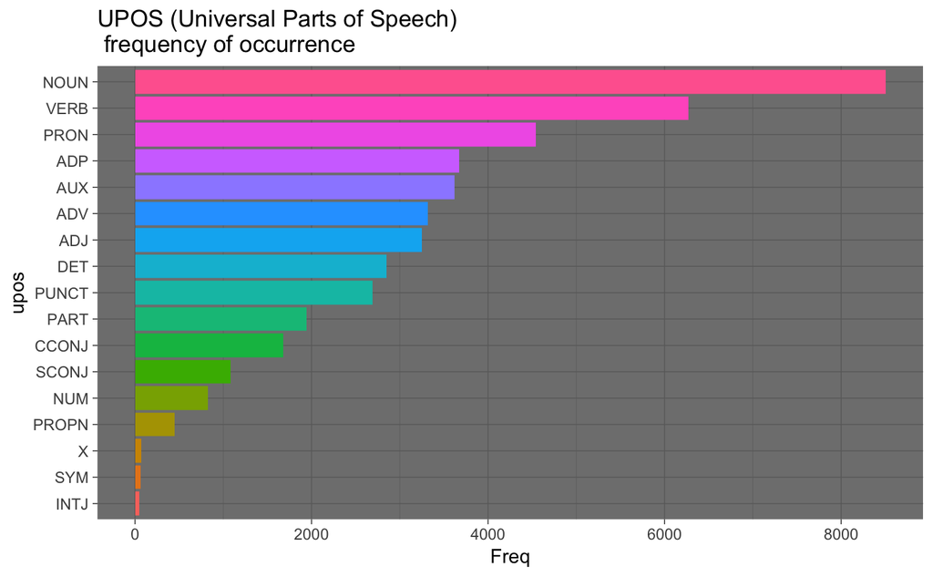

```r
verbatim_tokens %>%
  count(upos,sort = TRUE) %>%
  mutate(upos = reorder(upos,n))%>%
  ggplot(aes(x=upos,y=n,fill=upos))+
  ggplot2::geom_bar(stat = "identity")+
  ggplot2::theme_dark()+
  ggplot2::coord_flip()+
  ggplot2::theme(legend.position = "none")+
  ggplot2::labs(title = "UPOS (Universal Parts of Speech)\n frequency of occurrence",
         y = "Freq")
```

```r
verbatim_tokens %>% filter(upos %in% c("X"))
```

| doc_id | paragraph_id | sentence_id | sentence | start | end | term_id | token_id | token | lemma | upos | xpos | feats | head_token_id | dep_rel | deps | misc |
| --- | --- | --- | --- | --- | --- | --- | --- | --- | --- | --- | --- | --- | --- | --- | --- | --- |
| 85 | 1 | 1 | Non performance... unfulfilled promise.. | 1 | 3 | 1 | 1 | Non | non | X | FW | Foreign=Yes | 2 | compound | NA | NA |
| 153 | 1 | 2 | We had no broadband for over 5 weeks and cost us a lot in phone data etc | 193 | 195 | 38 | 17 | etc | etc | X | FW | NA | 16 | advmod | NA | SpacesAfter=\\n |
| 262 | 1 | 1 | 10 | 1 | 2 | 1 | 1 | 10 | 10 | X | LS | NA | 0 | root | NA | SpacesAfter=\\n |
| 288 | 1 | 1 | 5. | 1 | 1 | 1 | 1 | 5 | 5 | X | LS | NA | 0 | root | NA | SpaceAfter=No |
| 317 | 1 | 2 | The Customer service is completely non existing. | 72 | 74 | 14 | 6 | non | non | X | AFX | NA | 7 | advmod | NA | NA |
| 318 | 1 | 3 | 30/12/84. | 75 | 82 | 20 | 1 | 30/12/84 | 30/12/84 | X | LS | NA | 0 | root | NA | SpaceAfter=No |
| 338 | 1 | 1 | 8 | 1 | 1 | 1 | 1 | 8 | 8 | X | LS | NA | 0 | root | NA | SpacesAfter=\\n |
| 341 | 1 | 1 | company makes it easy to pay x | 30 | 30 | 7 | 7 | x | x | X | ADD | NA | 6 | advmod | NA | SpacesAfter=\\n |
| 408 | 1 | 3 | I was supposed to be connected 3 days ago, but will likely be waiting until mid February. | 227 | 229 | 47 | 17 | mid | mid | X | AFX | NA | 18 | compound | NA | NA |
| 444 | 1 | 1 | 10 | 1 | 2 | 1 | 1 | 10 | 10 | X | LS | NA | 0 | root | NA | SpacesAfter=\\n |

[output cut: 61 more lines]

| doc_id | paragraph_id | sentence_id | sentence | start | end | term_id | token_id | token | lemma | upos | xpos | feats | head_token_id | dep_rel | deps | misc |
| --- | --- | --- | --- | --- | --- | --- | --- | --- | --- | --- | --- | --- | --- | --- | --- | --- |
| 21 | 1 | 1 | Because 80% of me would recommend you to a friend or family member. | 11 | 11 | 3 | 3 | % | % | SYM | NN | Number=Sing | 7 | nsubj | NA | NA |
| 36 | 1 | 1 | ce � | 4 | 4 | 2 | 2 | � | � | SYM | $ | NA | 1 | discourse | NA | SpacesAfter=\\n |
| 83 | 1 | 3 | I stayed home todsy for my appointment (set between 8am-1pm) an engineer came out at roughly 8.30 and was gone within minutes. | 109 | 109 | 23 | 13 | - | - | SYM | SYM | NA | 15 | case | NA | SpaceAfter=No |
| 83 | 1 | 8 | So I've stayed home ALL day for an 8am-1pm slot to STILL not have broadband. | 467 | 467 | 108 | 12 | - | - | SYM | SYM | NA | 15 | case | NA | SpaceAfter=No |
| 91 | 1 | 1 | It's taken 3/4 months to get supply and me constantly chasing in order to achieve it! | 13 | 13 | 5 | 5 | / | / | SYM | SYM | NA | 6 | case | NA | SpaceAfter=No |
| 136 | 1 | 3 | I am still waiting for my faster product TO THE PREMISES CONNECTION after a month long wait Incompetent staff stating clearly that the appointment is booked then the next person tells me it was never … | 715 | 715 | 120 | 94 | % | % | SYM | NN | Number=Sing | 95 | obl:npmod | NA | NA |
| 176 | 1 | 2 | 4 x 50min phone calls, different reasons from each of them, twice promised connection, both not delivered | 92 | 92 | 19 | 2 | x | x | SYM | SYM | NA | 3 | case | NA | NA |
| 177 | 1 | 1 | STOP | 1 | 4 | 1 | 1 | STOP | stop | SYM | NFP | NA | 0 | root | NA | SpacesAfter=\\n |
| 215 | 1 | 1 | The service we have received since ordering faster broadband has been an absolute joke from start to finish � | 109 | 109 | 19 | 19 | � | � | SYM | $ | NA | 14 | punct | NA | SpacesAfter=\\n |
| 230 | 1 | 1 | Because everything company have done has been 100% | 50 | 50 | 9 | 9 | % | % | SYM | NN | Number=Sing | 0 | root | NA | SpacesAfter=\\n |

[output cut: 55 more lines]

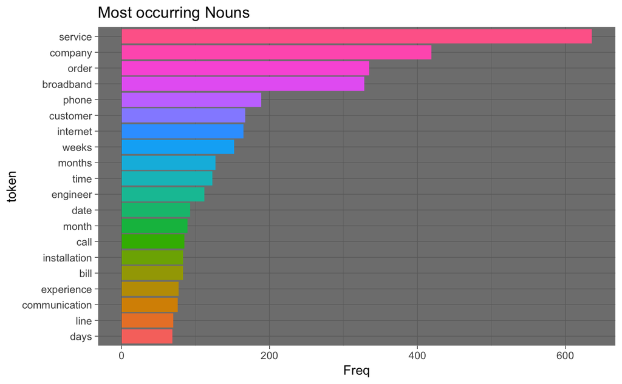

```r
## NOUNS
verbatim_tokens %>%
  filter(upos %in% c("NOUN"))%>%
  count(token,sort = TRUE) %>%
  top_n(20)%>%
  mutate(token = reorder(token,n))%>%
  ggplot(aes(x=token,y=n,fill=token))+
  geom_bar(stat = "identity")+
  theme_dark()+
  coord_flip()+
  theme(legend.position = "none")+
  labs(title = "Most occurring Nouns",
         y = "Freq")
```

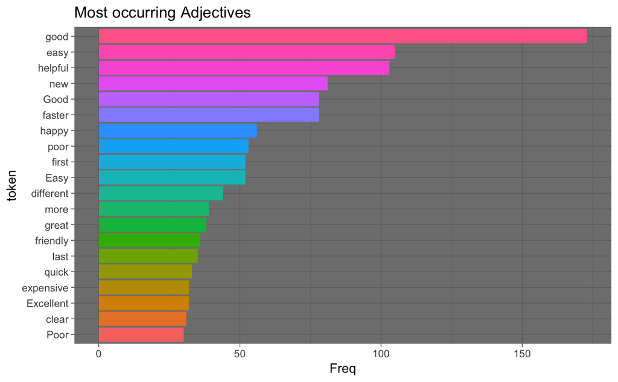

```r
## NOUNS
verbatim_tokens %>%
  filter(upos %in% c("ADJ"))%>%
  count(token,sort = TRUE) %>%
  top_n(20)%>%
  mutate(token = reorder(token,n))%>%
  ggplot(aes(x=token,y=n,fill=token))+
  geom_bar(stat = "identity")+
  theme_dark()+
  coord_flip()+
  theme(legend.position = "none")+
  labs(title = "Most occurring Adjectives",
         y = "Freq")
```

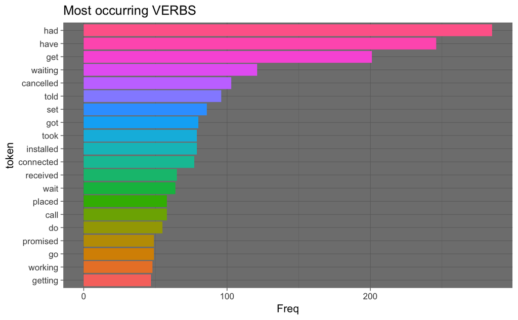

```r
## Verbs
verbatim_tokens %>%
  filter(upos %in% c("VERB"))%>%
  count(token,sort = TRUE) %>%
  top_n(20)%>%
  mutate(token = reorder(token,n))%>%
  ggplot(aes(x=token,y=n,fill=token))+
  geom_bar(stat = "identity")+
  theme_dark()+
  coord_flip()+
  theme(legend.position = "none")+
  labs(title = "Most occurring VERBS",
         y = "Freq")
```

## TOP NOUN—VERB Pairs as Keyword pairs

A: adjective

C: coordinating conjuction

D: determiner

M: modifier of verb

N: noun or proper noun

P: preposition

O: other elements

```r
table(as_phrasemachine(verbatim_tokens$upos, type = "upos"))
```

```
    A     C     D     M     N     O     P     V
 4074  2761  2849  5266 13493  2876  3672  9891
```

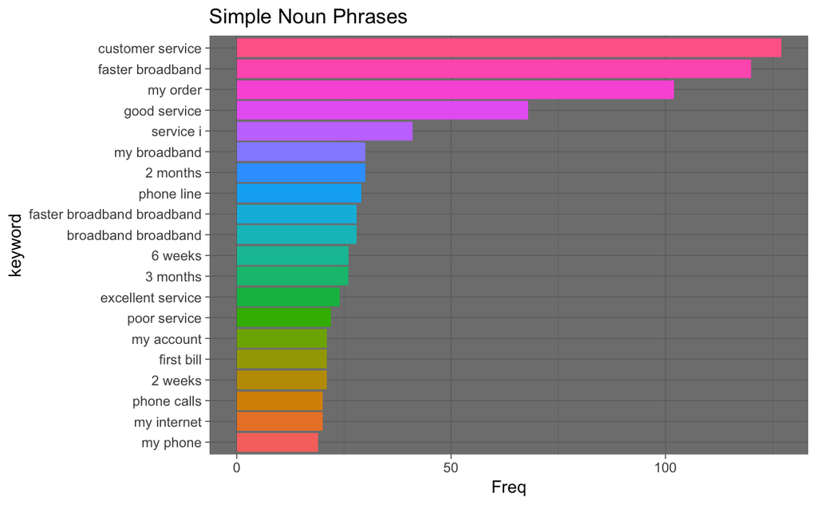

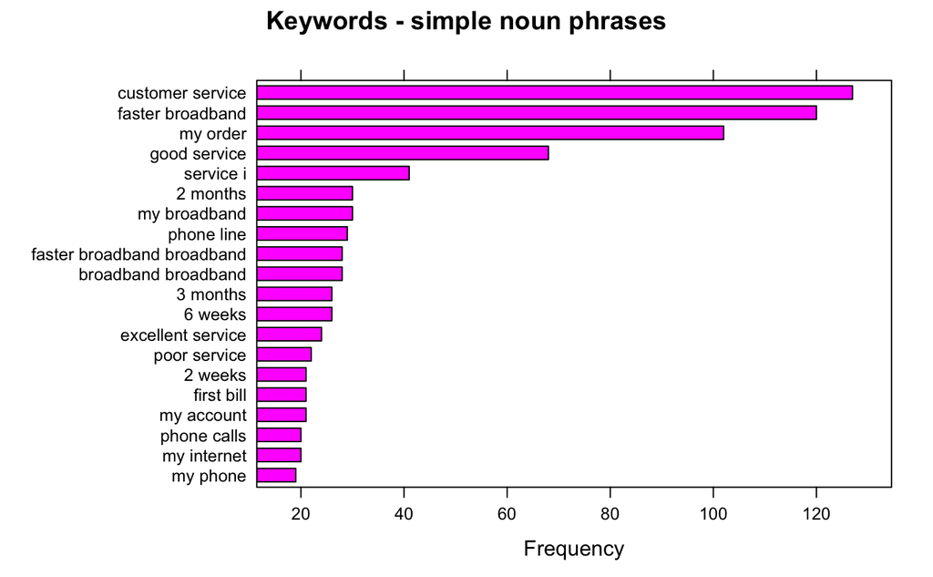

```r
stats <- subset(noun_adj_phrases, ngram > 1 & freq > 3)
stats$key <- factor(stats$keyword, levels = rev(stats$keyword))
barchart(key ~ freq, data = head(stats, 20), col = "magenta",
         main = "Keywords - simple noun phrases", xlab = "Frequency")
```

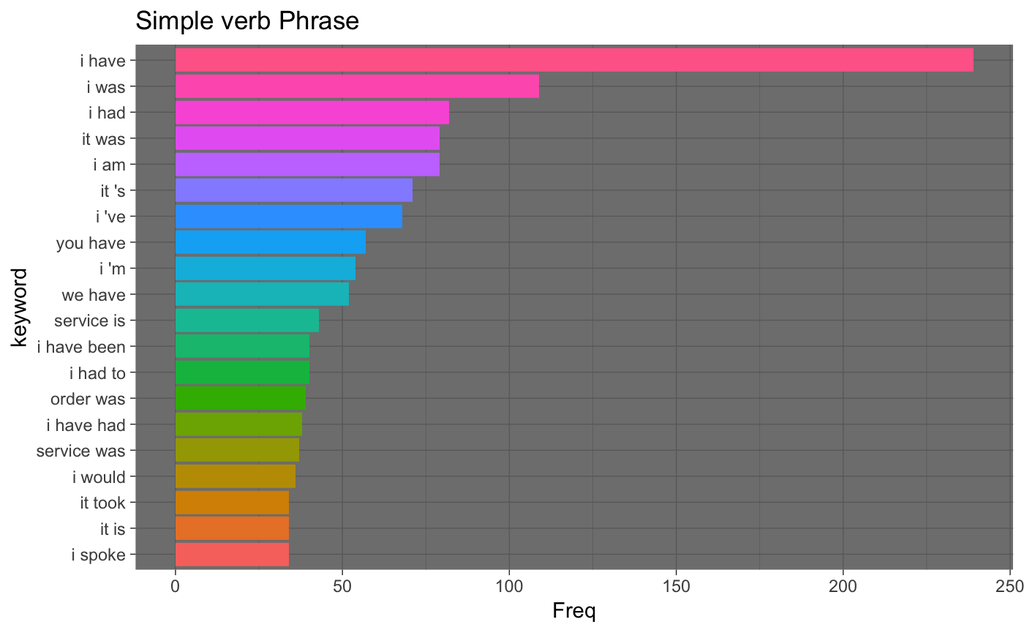

```r
verb_phrases <- keywords_phrases(x = verbatim_tokens$phrase_tag,
                          term = tolower(verbatim_tokens$token),
                          pattern = "((A|N)*N(P+D*(A|N)*N)*P*(M|V)*V(M|V)*|(M|V)*V(M|V)*D*(A|N)*N(P+D*(A|N)*N)*|(M|V)*V(M|V)*(P+D*(A|N)*N)+|(A|N)*N(P+D*(A|N)*N)*P*((M|V)*V(M|V)*D*(A|N)*N(P+D*(A|N)*N)*|(M|V)*V(M|V)*(P+D*(A|N)*N)+))",
                          is_regex = TRUE, detailed = FALSE)
verb_phrases %>% filter(ngram > 1 & freq > 2) %>% arrange(desc(freq)) %>% head(20) %>%
  mutate(keyword = reorder(keyword,freq)) %>%
  ggplot(aes(x = keyword, y=freq,fill = keyword)) +
   geom_bar(stat = "identity")+
  theme_dark()+
  coord_flip()+
  theme(legend.position = "none")+
  labs(title = "Simple verb Phrase",
         y = "Freq")
```

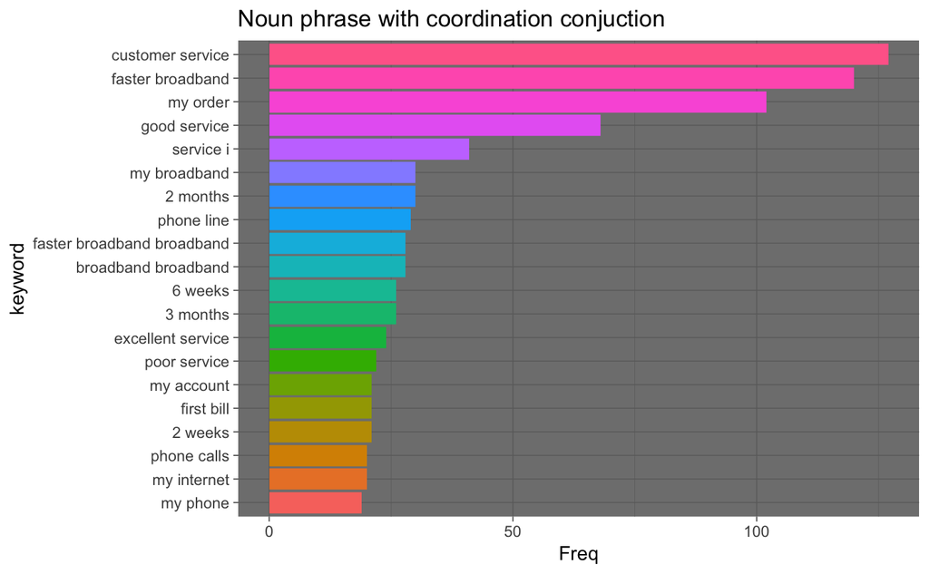

```r
noun_cord_conj_phrases <- keywords_phrases(x = verbatim_tokens$phrase_tag,
                          term = tolower(verbatim_tokens$token),
                          pattern = "((A(CA)*|N)*N((P(CP)*)+(D(CD)*)*(A(CA)*|N)*N)*(C(D(CD)*)*(A(CA)*|N)*N((P(CP)*)+(D(CD)*)*(A(CA)*|N)*N)*)*)",
                          is_regex = TRUE, detailed = FALSE)
noun_cord_conj_phrases %>% filter(ngram > 1 & freq > 2) %>% arrange(desc(freq)) %>% head(20) %>%
  mutate(keyword = reorder(keyword,freq)) %>%
  ggplot(aes(x = keyword, y=freq,fill = keyword)) +
   geom_bar(stat = "identity")+
  theme_dark()+
  coord_flip()+
  theme(legend.position = "none")+
  labs(title = "Noun phrase with coordination conjuction",
         y = "Freq")
```

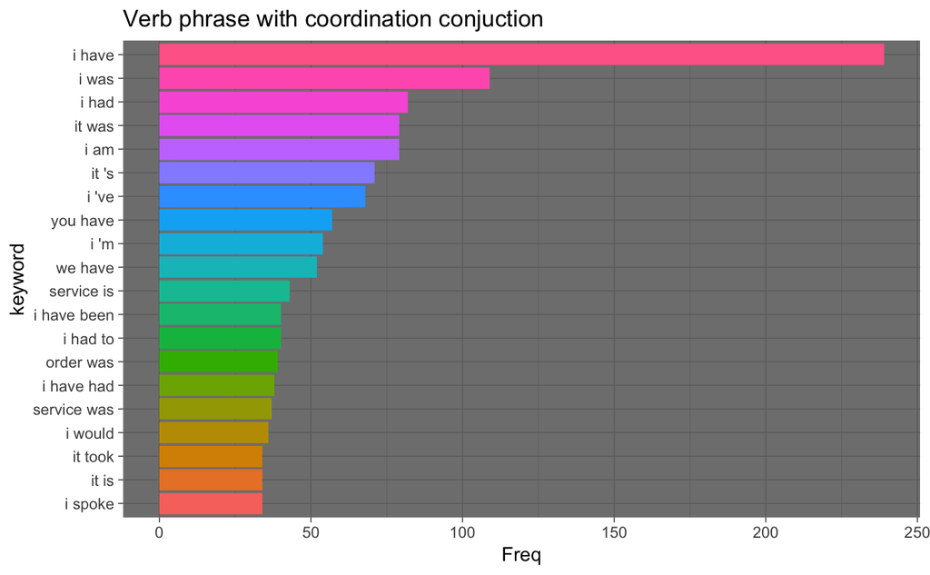

```r
verb_cord_conj_phrases <- keywords_phrases(x = verbatim_tokens$phrase_tag,
                          term = tolower(verbatim_tokens$token),
                          pattern = "(((A(CA)*|N)*N((P(CP)*)+(D(CD)*)*(A(CA)*|N)*N)*(C(D(CD)*)*(A(CA)*|N)*N((P(CP)*)+(D(CD)*)*(A(CA)*|N)*N)*)*)(P(CP)*)*(M(CM)*|V)*V(M(CM)*|V)*(C(M(CM)*|V)*V(M(CM)*|V)*)*|(M(CM)*|V)*V(M(CM)*|V)*(C(M(CM)*|V)*V(M(CM)*|V)*)*(D(CD)*)*((A(CA)*|N)*N((P(CP)*)+(D(CD)*)*(A(CA)*|N)*N)*(C(D(CD)*)*(A(CA)*|N)*N((P(CP)*)+(D(CD)*)*(A(CA)*|N)*N)*)*)|(M(CM)*|V)*V(M(CM)*|V)*(C(M(CM)*|V)*V(M(CM)*|V)*)*((P(CP)*)+(D(CD)*)*(A(CA)*|N)*N)+|((A(CA)*|N)*N((P(CP)*)+(D(CD)*)*(A(CA)*|N)*N)*(C(D(CD)*)*(A(CA)*|N)*N((P(CP)*)+(D(CD)*)*(A(CA)*|N)*N)*)*)(P(CP)*)*((M(CM)*|V)*V(M(CM)*|V)*(C(M(CM)*|V)*V(M(CM)*|V)*)*(D(CD)*)*((A(CA)*|N)*N((P(CP)*)+(D(CD)*)*(A(CA)*|N)*N)*(C(D(CD)*)*(A(CA)*|N)*N((P(CP)*)+(D(CD)*)*(A(CA)*|N)*N)*)*)|(M(CM)*|V)*V(M(CM)*|V)*(C(M(CM)*|V)*V(M(CM)*|V)*)*((P(CP)*)+(D(CD)*)*(A(CA)*|N)*N)+))",
                          is_regex = TRUE, detailed = FALSE)
verb_cord_conj_phrases %>% filter(ngram > 1 & freq > 2) %>% arrange(desc(freq)) %>% head(20) %>%
  mutate(keyword = reorder(keyword,freq)) %>%
  ggplot(aes(x = keyword, y=freq,fill = keyword)) +
   geom_bar(stat = "identity")+
  theme_dark()+
  coord_flip()+
  theme(legend.position = "none")+
  labs(title = "Verb phrase with coordination conjuction",
         y = "Freq")
```

## Automated keywords extraction using RAKE

Rapid Automatic Keyword Extraction(RAKE) algorithm is one of the most popular(unsupervised) algorithms for extracting keywords in Information retrieval. It looks for keywords by looking to a contiguous sequence of words which do not contain irrelevant words. Frequency statistics of words are nice but most of the time, you are getting stuck in words which only make sense in combination with other words. Hence you want to find keywords which are a combination of words.

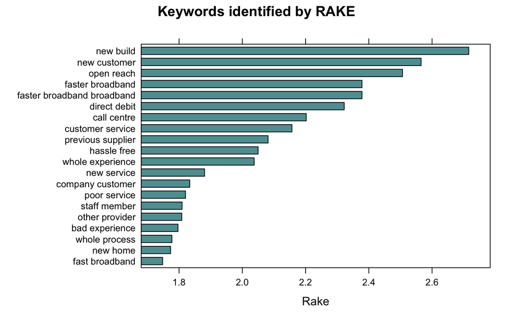

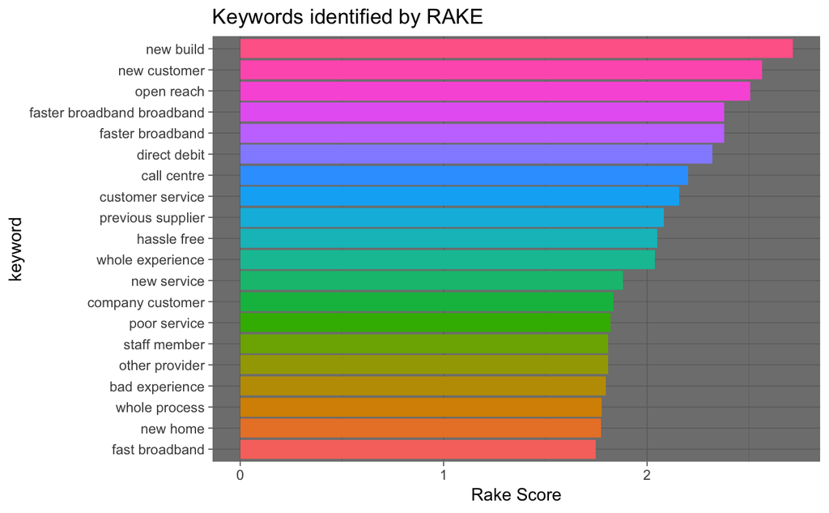

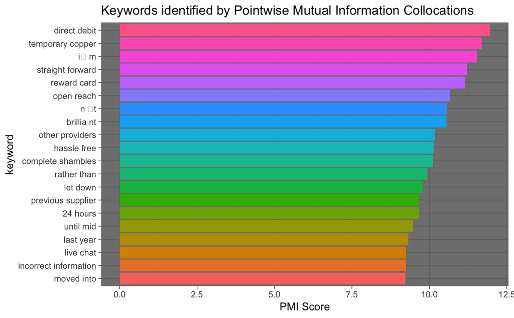

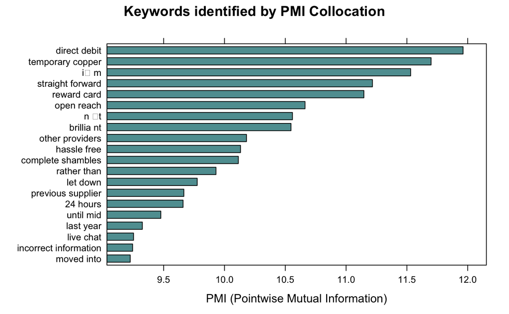

```r
pmi_keywords$key <- factor(pmi_keywords$keyword, levels = rev(pmi_keywords$keyword))
barchart(key ~ pmi, data = head(subset(pmi_keywords, freq > 3), 20), col = "cadetblue",
         main = "Keywords identified by PMI Collocation",
         xlab = "PMI (Pointwise Mutual Information)")
```

## Co-occurrences

Co-occurrences allow to see how words are used either in the same sentence or next to each other. This R package make creating co-occurrence graphs using the relevant Parts of Speech tags as easy as possible.

Nouns / adjectives used in same sentence In this example we look how many times nouns and adjectives are used in the same sentence.

| term1 | term2 | cooc |
| --- | --- | --- |
| broadband | faster | 166 |
| customer | service | 156 |
| good | service | 135 |
| company | service | 81 |
| poor | service | 63 |
| broadband | month | 61 |
| order | time | 60 |
| broadband | company | 57 |
| broadband | week | 56 |
| broadband | order | 55 |

[output cut: 990 more lines]

```r
cooc
```

[output not shown]

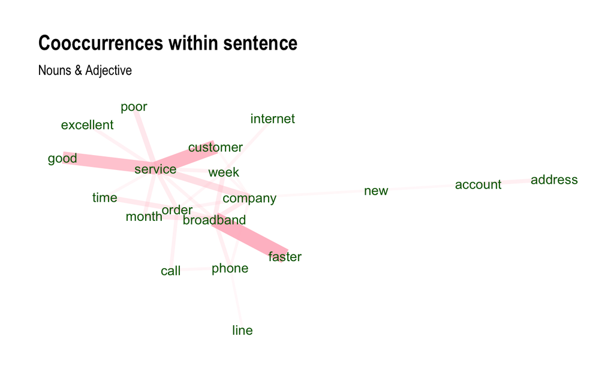

```r
library(igraph)
library(ggraph)
library(ggplot2)
wordnetwork <- head(cooc, 30)
wordnetwork <- graph_from_data_frame(wordnetwork)
ggraph(wordnetwork, layout = "fr") +
  geom_edge_link(aes(width = cooc, edge_alpha = cooc), edge_colour = "pink") +
  geom_node_text(aes(label = name), col = "darkgreen", size = 4) +
  theme_graph(base_family = "Arial Narrow") +
  theme(legend.position = "none") +
  labs(title = "Cooccurrences within sentence", subtitle = "Nouns & Adjective")
```

## Nouns / adjectives which follow one another

If you are interested in visualising which words follow one another. This can be done by calculating word cooccurrences of a specific Parts of Speech type which follow one another where you can specify how far away you want to look regarding ‘following one another’ (in the example below we indicate skipgram = 1 which means look to the next word and the word after that).

```r
cooc <- cooccurrence(verbatim_tokens$lemma,
                     relevant = verbatim_tokens$upos %in% c("NOUN", "ADJ"),
                     skipgram = 1)
head(cooc)
```

|  | term1 | term2 | cooc |
| --- | --- | --- | --- |
| 1 | faster | broadband | 151 |
| 2 | customer | service | 140 |
| 3 | good | service | 87 |
| 4 | poor | service | 39 |
| 5 | broadband | broadband | 31 |
| 6 | excellent | service | 31 |

[output not shown]

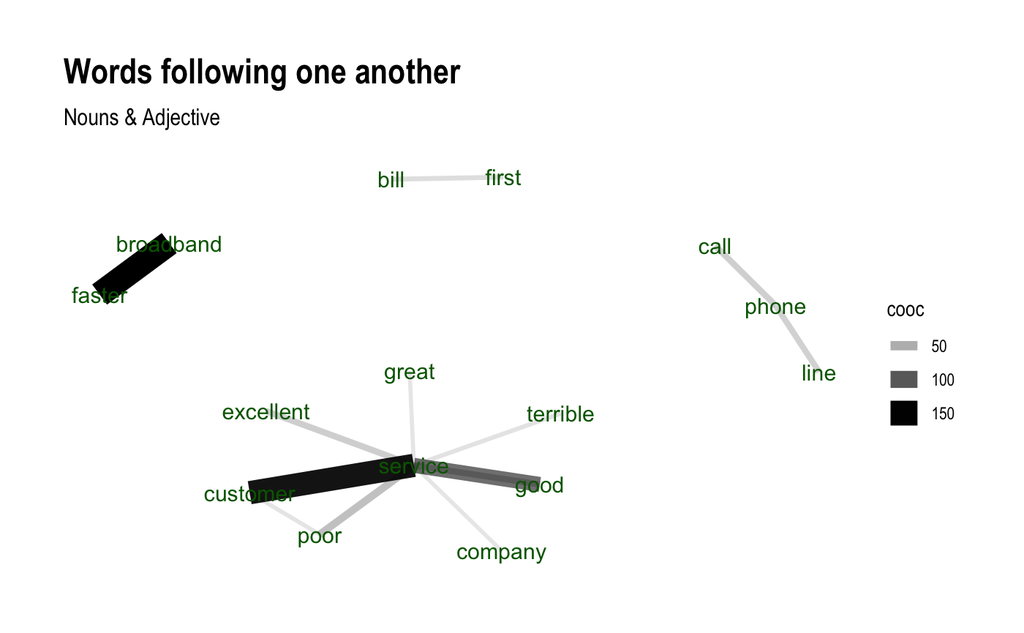

```r
library(igraph)
library(ggraph)
library(ggplot2)
wordnetwork <- head(cooc, 15)
wordnetwork <- graph_from_data_frame(wordnetwork)
ggraph(wordnetwork, layout = "fr") +
  geom_edge_link(aes(width = cooc, edge_alpha = cooc)) +
  geom_node_text(aes(label = name), col = "darkgreen", size = 4) +
  theme_graph(base_family = "Arial Narrow") +
  labs(title = "Words following one another", subtitle = "Nouns & Adjective")
```

## Keyword based topic modelling

You mostly get better, more interpretable results in topic models if you include compound keywords in the model. Let’s show the steps how you can accomplish this.

1. First get keywords using either the keywords_rake, keywords_phrases, keywords_collocation functions or with functionality from the textrank R package using textrank_keywords() method.
2. Use function txt_recode_ngram to recode words to keywords. This will replace a sequence of words with its compound multi-word expression by first starting with words which contain more terms.
3. Use docment_term_frequencies() to calculate freqs of the compound words you just created
4. Use document_term_matrix on step 3.
5. Build the LDA model on step 4

In the below example, we are building a topic model on all nouns, all compound keywords which consists of nouns and adjectives and on all identified noun phrases.

```r
dtm <- document_term_matrix(verbatim_tokens = dtm)
```

[output not shown]

Once we have our document/term/matrix, topic modelling is simple. Keep in mind that you need to tune your topic model, which is not done below. See the topicmodels and ldatuning R package which show you how to do that.

```r
library(topicmodels)
m <- LDA(dtm, k = 5, method = "Gibbs",
         control = list(nstart = 5, burnin = 2000, best = TRUE, seed = 1:5))
```

You’ll see that the topic model now includes keywords

```r
topicterminology
```

|  | term | prob |
| --- | --- | --- |
| 1 | Good service | 0.16554673 |
| 2 | phone line | 0.15943800 |
| 3 | Excellent service | 0.08002443 |
| 4 | first bill | 0.08002443 |

|  | term | prob |
| --- | --- | --- |
| 1 | good service | 0.23387723 |
| 2 | company sport | 0.06293706 |
| 3 | phone calls | 0.05516706 |
| 4 | poor service | 0.05516706 |

|  | term | prob |
| --- | --- | --- |
| 1 | faster broadband | 0.62840837 |
| 2 | good experience | 0.05136335 |
| 3 | poor customer service | 0.05136335 |
| 4 | whole process | 0.03868104 |

|  | term | prob |
| --- | --- | --- |
| 1 | Customer service | 0.14596950 |
| 2 | faster broadband | 0.13144517 |
| 3 | X company | 0.12418301 |
| 4 | that I | 0.09513435 |

|  | term | prob |
| --- | --- | --- |
| 1 | customer service | 0.43572841 |
| 2 | phone calls | 0.07976269 |
| 3 | customer services | 0.05998682 |
| 4 | new build | 0.05998682 |

```
NA
```

## do the same but with textRank()

```r
head(dtm)
```

```
[1] 0 0 0 0 0 0
```

```r
library(topicmodels)
m <- LDA(dtm, k = 5, method = "Gibbs",
         control = list(nstart = 5, burnin = 2000, best = TRUE, seed = 1:5))
```

You’ll see that the topic model now includes keywords

```r
topicterminology <- predict(m, type = "terms", min_posterior = 0.10, min_terms = 4)
topicterminology
```

|  | term | prob |
| --- | --- | --- |
| 1 | my order | 0.14356436 |
| 2 | month | 0.06539865 |
| 3 | day | 0.04194893 |
| 4 | customer service | 0.03673788 |

|  | term | prob |
| --- | --- | --- |
| 1 | service | 0.27541978 |
| 2 | engineer | 0.12849813 |
| 3 | bill | 0.04920709 |
| 4 | installation | 0.04454291 |

|  | term | prob |
| --- | --- | --- |
| 1 | company | 0.14084832 |
| 2 | broadband | 0.12701706 |
| 3 | faster broadband | 0.06938681 |
| 4 | date | 0.04402951 |

|  | term | prob |
| --- | --- | --- |
| 1 | phone | 0.11493411 |
| 2 | internet | 0.10517326 |
| 3 | call | 0.05392875 |
| 4 | Service | 0.04416789 |

|  | term | prob |
| --- | --- | --- |
| 1 | company | 0.19806655 |
| 2 | order | 0.19357014 |
| 3 | one | 0.07441547 |
| 4 | week | 0.04743705 |

```
NA
```

### we can get topic predictions using predict on the same dtm

| doc_id | topic | topic_label | topic_prob | topic_probdiff_2nd | topic_001 | topic_002 | topic_003 | topic_004 | topic_005 |
| --- | --- | --- | --- | --- | --- | --- | --- | --- | --- |
| 1 | 4 | topic_004 | 0.2156863 | 0.01960784 | 0.1960784 | 0.1960784 | 0.1960784 | 0.2156863 | 0.1960784 |
| 100 | 5 | topic_005 | 0.2156863 | 0.01960784 | 0.1960784 | 0.1960784 | 0.1960784 | 0.1960784 | 0.2156863 |
| 1000 | 4 | topic_004 | 0.2407407 | 0.03703704 | 0.1851852 | 0.1851852 | 0.1851852 | 0.2407407 | 0.2037037 |
| 1001 | 1 | topic_001 | 0.2115385 | 0.00000000 | 0.2115385 | 0.1923077 | 0.1923077 | 0.2115385 | 0.1923077 |
| 1002 | 5 | topic_005 | 0.2156863 | 0.01960784 | 0.1960784 | 0.1960784 | 0.1960784 | 0.1960784 | 0.2156863 |
| 1003 | 4 | topic_004 | 0.2156863 | 0.01960784 | 0.1960784 | 0.1960784 | 0.1960784 | 0.2156863 | 0.1960784 |
| 1006 | 5 | topic_005 | 0.2156863 | 0.01960784 | 0.1960784 | 0.1960784 | 0.1960784 | 0.1960784 | 0.2156863 |
| 1007 | 1 | topic_001 | 0.2156863 | 0.01960784 | 0.2156863 | 0.1960784 | 0.1960784 | 0.1960784 | 0.1960784 |
| 1008 | 4 | topic_004 | 0.2156863 | 0.01960784 | 0.1960784 | 0.1960784 | 0.1960784 | 0.2156863 | 0.1960784 |
| 1009 | 4 | topic_004 | 0.2156863 | 0.01960784 | 0.1960784 | 0.1960784 | 0.1960784 | 0.2156863 | 0.1960784 |

[output cut: 990 more lines]

### this gives us doc_id for each document in a particular topic

```r
table(predict(m, newdata = dtm, type = "topics") %>% select(topic_label))
```

```
topic_001 topic_002 topic_003 topic_004 topic_005
      331       323       293       257       256
```

### we can see that more topics are in topic one… let’s get all sentences for this topic 1

[output not shown]

[output cut: 315 more lines]

## we can get all the sentences in that topic by:

| doc_id | paragraph_id | sentence_id | sentence | upos | lemma |
| --- | --- | --- | --- | --- | --- |
| 1001 | 1 | 1 | t work as I never get a call back | ADJ | t |
| 1007 | 1 | 1 | I think totally incompetent sums it up as I am still not connected properly there is no communication and you never reply to any on going issues | PRON | I |
| 101 | 1 | 1 | Because live chat is so useful | SCONJ | because |
| 1022 | 1 | 1 | Why not | ADV | why |
| 1679 | 1 | 1 | Why not | ADV | why |
| 1035 | 1 | 1 | Good service usually | ADJ | good |
| 1050 | 1 | 1 | You delayed me installations date | PRON | you |
| 1060 | 1 | 1 | Hmmm order my internet on Feb still waiting | INTJ | hmmm |
| 1069 | 1 | 1 | be on up to 50mb), spent 70 mins on phone with you Saturday ... oh and failed to ring back yesterday as promised to book in engineer today. | AUX | be |
| 1095 | 1 | 1 | Very poor service with order being cancelled several times without my knowledge and appointments being changed | ADV | very |

[output cut: 332 more lines]

## now we can run textrank on these sentences to create a summary sentences for this topic

```r
terminology <- topic1 %>% filter(upos %in% c("NOUN", "ADJ")) %>%
                                    select(sentence_id,lemma) %>%
                                    distinct(sentence_id,lemma)
terminology
```

| sentence_id | lemma |
| --- | --- |
| 1 | t |
| 1 | good |
| 2 | great |
| 1 | terrible |
| 3 | engineer |
| 6 | phone |
| 1 | first |
| 1 | people |
| 2 | company |
| 1 | deal |

[output cut: 41 more lines]

```r
## Limit the number of candidates with the minhash algorithm
library(textreuse)
minhash <- minhash_generator(n = 1000, seed = 123456789) # "n" needs to be double of "bands"
candidates <- textrank_candidates_lsh(x = terminology$lemma,
                                      sentence_id = terminology$sentence_id,
                                      minhashFUN = minhash,
                                      bands = 500)
dim(candidates)
```

```
[1] 3 2
```

```r
summary(tr, n = 20, keep.sentence.order = TRUE)
```

[output not shown]

## Other option to build document term matricis

In the above example, nouns which were part of a compound multi-word-expression (mwe) were replaced by the multi-word-expression. Sometimes however, you want to keep the noun as well as the multi-word expression in the topic model even if the noun is always part of a multi-word expression. You can do this as follows.

```r
## Recode tokens to keywords, if it is not in the list of tokens, set to NA
verbatim_tokens$mwe <- txt_recode_ngram(verbatim_tokens$token,
                                        compound = keyw_rake$keyword, ngram = keyw_rake$ngram)
verbatim_tokens$mwe <- ifelse(verbatim_tokens$mwe %in% keyw_rake$keyword, verbatim_tokens$mwe, NA)

## nouns
verbatim_tokens$term_noun <- ifelse(verbatim_tokens$upos %in% "NOUN", verbatim_tokens$token, NA)

## Build document/term/matrix
dtm <- document_term_frequencies(verbatim_tokens, document = "topic_level_id", term = c("term_noun", "mwe"))
dtm <- document_term_matrix(x = dtm)
dtm <- dtm_remove_lowfreq(dtm, minfreq = 3)
m <- LDA(dtm, k = 5, method = "Gibbs",
         control = list(nstart = 5, burnin = 2000, best = TRUE, seed = 1:5))

predict(m, type = "terms", min_posterior = 0.10, min_terms = 4)
```

## Topic modelling only on specific POS tags

You can easily go from annotated data.frame (verbatim_tokens) to a document-term-matrix which is used by a lot of other text mining R packages. In this case, we will build topics at the sentence level.

The advantage of this package over other packages is that

1. topic modelling can be done directly on the right terms as these can be easily identified with the Parts of Speech tag: mostly you are only interested in nouns and verbs or only in finding topics adjectives if you are interested in sentiment clustering.
2. you don’t have to build a long list of stopwords any more
3. you can work based on the lemma instead of the plain token, making the words resemble more each other
4. you can easily include compound keywords

Below we fit a topic model on the nouns only.

```r
verbatim_tokens$topic_level_id <- unique_identifier(verbatim_tokens, fields = c("doc_id", "paragraph_id", "sentence_id"))

## Get a data.frame with 1 row per topic_level_id/lemma
dtf <- verbatim_tokens %>% filter(upos %in% c("NOUN"))

dtf <- document_term_frequencies(dtf, document = "topic_level_id", term = "lemma")

head(dtf)
```

```r
## Create a document/term/matrix for building a topic model
dtm <- document_term_matrix(x = dtf)
## Remove words which do not occur that much
dtm_clean <- dtm_remove_lowfreq(dtm, minfreq = 5)
head(dtm_colsums(dtm_clean),20)
```

## you can remove terms you dont like or get the top 50 terms

```r
##  keep top 50 nouns based on mean term-frequency-inverse document frequency
dtm_clean <- dtm_remove_tfidf(dtm_clean, top = 50)
```

## Once we have our document/term/matrix, topic modelling is simple

```r
library(topicmodels)
m <- LDA(dtm_clean, k = 4, method = "Gibbs",
         control = list(nstart = 5, burnin = 2000, best = TRUE, seed = 1:5))

topicterminology <- predict(m, type = "terms", min_posterior = 0.025, min_terms = 5)
scores <- predict(m, newdata = dtm, type = "topics")
```

## Topic visualisation

Once you have topics, visualising these can also be easily done with the igraph and ggraph packages. Below one possible plot is shown. It shows for a certain topic the co-occurrence of terms

```r
library(igraph)
library(ggraph)
library(ggplot2)
x_topics <- merge(verbatim_tokens, scores, by.x="topic_level_id", by.y="doc_id")
wordnetwork <- subset(x_topics, topic %in% 1 & lemma %in% topicterminology[[1]]$term)
wordnetwork <- cooccurrence(wordnetwork, group = c("topic_level_id"), term = "lemma")
wordnetwork <- graph_from_data_frame(wordnetwork)
ggraph(wordnetwork, layout = "fr") +
  geom_edge_link(aes(width = cooc, edge_alpha = cooc), edge_colour = "pink")  +
  geom_node_text(aes(label = name), col = "darkgreen", size = 4) +
  theme_graph(base_family = "Arial Narrow") +
  labs(title = "Words in topic 1 ", subtitle = "Nouns & Adjective cooccurrence")
```

## Text Summarisation using TextRank

```r
head(verbatim_tokens[, c("sentence_id", "lemma", "upos")], 10)
```

## Textrank for keyword extraction

For extracting keywords in the verbatim, we are providing it a vector of words and a vector of logicals indicating for each word if it is relevant. In the below case we consider only nouns, verbs and adjectives as relevant.

```r
library(textrank)
keyw <- textrank_keywords(verbatim_tokens$lemma,
                          relevant = verbatim_tokens$upos %in% c("NOUN", "VERB", "ADJ"))

class(keyw)
subset(keyw$keywords, ngram > 1 & freq > 1)
```

```r
stats <- subset(keyw$keywords, ngram > 1 & freq >= 5)
library(wordcloud)
wordcloud(words = stats$keyword, freq = stats$freq)
```

## Textrank for sentence ranking

The algorithm basically computes weights between sentences by looking which words are overlapping.

You probably do not want to look for overlap in words like ‘the’, ‘and’, ‘or’, … That is why, most of the time you probably will have already executed some Parts of Speech tagging in order to identify nouns, verbs, adjectives, … or you might have set up your own dictionary of words which you want to consider to find overlap between sentences.

### Step 1 - Define sentences and terminology

```r
sentences <- verbatim_tokens %>% distinct(sentence_id,sentence) %>% select(sentence_id,sentence)

terminology <- verbatim_tokens %>% filter(upos %in% c("NOUN", "ADJ")) %>%
                                    select(sentence_id,lemma) %>%
                                    distinct(sentence_id,lemma)
terminology
```

## Step 2 - Minhash

If there were 37 sentences. It gives 666 combinations of sentences to calculate word overlap. If you have a large number of sentences, this becomes computationally unfeasible.

That is why you can provide in the argument textrank_candidates, it is a data.frame with sentence combinations for which you want to compute the Jaccard distance. This can be used for example to reduce the number of sentence combinations by applying the Minhash algorithm as shown below.

The result is you saving computation time. For good settings on n and bands which should be set in conjunction with the textrank_dist function, have a look at the vignette of the textreuse package.

```r
## Limit the number of candidates with the minhash algorithm
library(textreuse)

minhash <- minhash_generator(n = 1000, seed = 123456789) # "n" needs to be double of "bands"

candidates <- textrank_candidates_lsh(x = terminology$lemma,
                                      sentence_id = terminology$sentence_id,
                                      minhashFUN = minhash,
                                      bands = 500)
dim(candidates)
```

```r
head(candidates)
```

## Step 3 - Apply text rank on sentences

```r
verbatim_tokens$textrank_id <- unique_identifier(verbatim_tokens, fields = c("doc_id", "paragraph_id", "sentence_id"))

tr <- textrank_sentences(data = unique(verbatim_tokens[, c("textrank_id", "sentence")]),
                         terminology = terminology,
                         textrank_candidates = candidates)

## see more than top 5 important sentences:

tr
```

```r
summary(tr, n = 20, keep.sentence.order = TRUE)
```

```r
summary(tr)
```

```r
model1 <- crf(y = x1$chunk_entity,
              x = x1[, grep("upos|lemma", colnames(x1), value = TRUE)],
              group = x1$doc_id,
              method = "lbfgs", options = list(max_iterations = 15))

stats1 <- summary(model1)
stats1

plot(stats1$iterations$loss, type = "b", xlab = "Iteration", ylab = "Loss")
```

```r
scores1 <- predict(model1,
                  newdata = x1[, grep("upos|lemma", colnames(x1))],
                  group = x1$doc_id)
table(scores1$label,x1$chunk_entity)
```

```r
scores1 <- predict(model1,
                  newdata = x1[, grep("upos|lemma", colnames(x1))],
                  group = x1$doc_id)
table(scores1$label)
```

```r
scores1
```

```r
which(scores1$label %in% c("B-COMPETITOR"))
```

```r
verbatim_tokens[276,]
```

```r
verbatim_tokens[311,]
```

```r
which(scores$label %in% c("I-VFM"))
```

```r
verbatim_tokens[315,]
```

```r
crfsuite_annotation_verbatim_to_annotate %>% filter(text %in% c("Clear instructions with a fair price offered"))
```

```r
#using RDRPOSTagger
devtools::install_github("bnosac/RDRPOSTagger", build_vignettes = TRUE)
```

```r
library(RDRPOSTagger)
```

```r
rdr_available_models()
#define the language and the type of tagger
tagger <- RDRPOSTagger::rdr_model(language = "English",annotation = "UniversalPOS")

rdr_tagging <- RDRPOSTagger::rdr_pos(object = tagger,x = verbatims$text)

#this adds d at the start of the doc_id. so stripping out the d
rdr_tagging <- rdr_tagging %>% mutate(doc_id = as.integer(readr::parse_number(doc_id))) %>% rename(upos = pos)

rdr_tagging
```

```r
table(rdr_tagging$upos)
```

```r
table(verbatim_tokens$upos)
```

```r
rdr_tagging %>% filter(upos %in% c("NUM"))
```

```r
verbatim_tokens %>% filter(upos %in% c("NUM"))
```

```r
x <- merge(crfsuite_annotation_verbatim_to_annotate,rdr_tagging) #throughs error

x <- merge(rdr_tagging,crfsuite_annotation_verbatim_to_annotate)

#creates dups so unduplicate
x <- x %>% distinct(doc_id,token_id,.keep_all = TRUE)
x

x <- crf_cbind_attributes(x, terms = c("upos"), by = "doc_id")



model2 <- crf(y = x$chunk_entity,
              x = x[, grep("upos|lemma", colnames(x), value = TRUE)],
              group = x$doc_id,
              method = "lbfgs", options = list(max_iterations = 15))

stats2 <- summary(model2)
stats2
```

```r
plot(stats2$iterations$loss, type = "b", xlab = "Iteration", ylab = "Loss")
```

```r
scores2 <- predict(model2,
                  newdata = x[, grep("upos|lemma", colnames(x))],
                  group = x$doc_id)
x$entity <- scores2$label
table(x$entity, x$chunk_entity)

table(scores2$label)
```

```r
table(scores1$label)
```

```r
which(scores1$label %in% c("COMPETITOR"))
```

```r
x_dedup[19,]
```

```r
x[872,]
```

```r
verbatim_tokens %>%
  count(upos,sort = TRUE) %>%
  mutate(upos = reorder(upos,n))%>%
  ggplot(aes(x=upos,y=n,fill=upos))+
  geom_bar(stat = "identity")+
  theme_dark()+
  coord_flip()+
  theme(legend.position = "none")+
  labs(title = "UPOS (Universal Parts of Speech)\n frequency of occurrence",
         y = "Freq")
```

```r
## NOUNS
verbatim_tokens %>%
  filter(upos %in% c("NOUN"))%>%
  count(token,sort = TRUE) %>%
  top_n(20)%>%
  mutate(token = reorder(token,n))%>%
  ggplot(aes(x=token,y=n,fill=token))+
  geom_bar(stat = "identity")+
  theme_dark()+
  coord_flip()+
  theme(legend.position = "none")+
  labs(title = "Most occurring Nouns",
         y = "Freq")
```

```r
## VERBS
verbatim_tokens %>%
  filter(upos %in% c("VERB"))%>%
  count(token,sort = TRUE) %>%
  top_n(10)%>%
  mutate(token = reorder(token,n))%>%
  ggplot(aes(x=token,y=n,fill=token))+
  geom_bar(stat = "identity")+
  theme_dark()+
  coord_flip()+
  theme(legend.position = "none")+
  labs(title = "Most occurring VERBS",
         y = "Freq")
```

```r
## ADJECTIVES
verbatim_tokens %>%
  filter(upos %in% c("ADJ"))%>%
  count(token,sort = TRUE) %>%
  top_n(10)%>%
  mutate(token = reorder(token,n))%>%
  ggplot(aes(x=token,y=n,fill=token))+
  geom_bar(stat = "identity")+
  theme_dark()+
  coord_flip()+
  theme(legend.position = "none")+
  labs(title = "Most occurring ADJ",
         y = "Freq")
```

Finding keywords Frequency statistics of words are nice but most of the time, you are getting stuck in words which only make sense in combination with other words. Hence you want to find keywords which are a combination of words.

Currently, this R package provides 3 methods to identify keywords in text

RAKE (Rapid Automatic Keyword Extraction) Collocation ordering using Pointwise Mutual Information Parts of Speech phrase sequence detection

```r
library(lattice)
## Using RAKE
stats <- keywords_rake(x = verbatim_tokens, term = "lemma", group = "doc_id",
                       relevant = verbatim_tokens$upos %in% c("NOUN", "ADJ"))

stats$key <- factor(stats$keyword, levels = rev(stats$keyword))

barchart(key ~ rake, data = head(subset(stats, freq > 3), 20), col = "cadetblue",
         main = "Keywords identified by RAKE",
         xlab = "Rake")
```

```r
stats %>% filter(freq > 3) %>%
  mutate(keyword = reorder(keyword,rake)) %>%
  head(20) %>%
  ggplot(aes(x=keyword,y = rake, fill=keyword))+
  geom_bar(stat = "identity")+
  theme_dark()+
  coord_flip()+
  theme(legend.position = "none")+
  labs(title = "Keywords based on RAKE ALGORITHM",
         y = "RAKE SCORE")
```

```r
stats %>% filter(freq > 10) %>%
  mutate(keyword = reorder(keyword,rake)) %>%
  head(20) %>%
  ggplot(aes(x=keyword,y = rake, fill=keyword))+
  geom_bar(stat = "identity")+
  theme_dark()+
  coord_flip()+
  theme(legend.position = "none")+
  labs(title = "Keywords based on RAKE ALGORITHM",
         y = "RAKE SCORE")
```

```r
## Collocation (words following one another)
stats4 <- keywords_collocation(x = verbatim_tokens,
                             term = "token", group = c("doc_id", "paragraph_id", "sentence_id"),
                             ngram_max = 4)
## Co-occurrences: How frequent do words occur in the same sentence, in this case only nouns or adjectives
stats5 <- cooccurrence(x = subset(verbatim_tokens, upos %in% c("NOUN", "ADJ")),
                     term = "lemma", group = c("doc_id", "paragraph_id", "sentence_id"))
## Co-occurrences: How frequent do words follow one another
stats6 <- cooccurrence(x = verbatim_tokens$lemma,
                     relevant = verbatim_tokens$upos %in% c("NOUN", "ADJ"))
## Co-occurrences: How frequent do words follow one another even if we would skip 2 words in between
stats7 <- cooccurrence(x = verbatim_tokens$lemma,
                     relevant = verbatim_tokens$upos %in% c("NOUN", "ADJ"), skipgram = 2)
head(stats4)
```

```r
library(igraph)
library(ggraph)
library(ggplot2)
wordnetwork <- head(stats4, 30)
wordnetwork <- graph_from_data_frame(wordnetwork)
ggraph(wordnetwork, layout = "fr") +
  geom_edge_link( edge_colour = "pink") +
  geom_node_text(aes(label = name), col = "darkgreen", size = 4) +
  theme_graph(base_family = "Arial Narrow") +
  theme(legend.position = "none") +
  labs(title = "Cooccurrences within 3 words distance", subtitle = "Nouns & Adjective")
```

```r
stats5 <- as.data.frame(stats5,detailed = TRUE)
head(stats5)
```

```r
class(stats6)
```

```r
stats7 <- textrank_keywords(verbatim_tokens$lemma,
                          relevant = verbatim_tokens$upos %in% c("NOUN", "ADJ"),
                          ngram_max = 8, sep = " ")
stats7 <- subset(stats7$keywords, ngram > 1 & freq >= 4)
library(wordcloud)
wordcloud(words = stats7$keyword, freq = stats$freq)
```

```r
## Simple noun phrases (a adjective+noun, pre/postposition, optional determiner and another adjective+noun)
verbatim_tokens$phrase_tag <- as_phrasemachine(verbatim_tokens$upos, type = "upos")
stats8 <- keywords_phrases(x = verbatim_tokens$phrase_tag, term = verbatim_tokens$token,
                         pattern = "(A|N)+N(P+D*(A|N)*N)*",
                         is_regex = TRUE, ngram_max = 4, detailed = FALSE)
head(subset(stats8, ngram > 2))
```

```r
## Using Pointwise Mutual Information Collocations
verbatim_tokens$word <- tolower(verbatim_tokens$token)
stats <- keywords_collocation(x = verbatim_tokens, term = "word", group = "doc_id")
stats$key <- factor(stats$keyword, levels = rev(stats$keyword))
barchart(key ~ pmi, data = head(subset(stats, freq > 3), 20), col = "cadetblue",
         main = "Keywords identified by PMI Collocation",
         xlab = "PMI (Pointwise Mutual Information)")
```

```r
## Using a sequence of POS tags (noun phrases / verb phrases)
verbatim_tokens$phrase_tag <- as_phrasemachine(verbatim_tokens$upos, type = "upos")
stats <- keywords_phrases(x = verbatim_tokens$phrase_tag, term = tolower(verbatim_tokens$token),
                          pattern = "(A|N)*N(P+D*(A|N)*N)*",
                          is_regex = TRUE, detailed = FALSE)
stats <- subset(stats, ngram > 1 & freq > 3)
stats$key <- factor(stats$keyword, levels = rev(stats$keyword))
barchart(key ~ freq, data = head(stats, 20), col = "cadetblue",
         main = "Keywords - simple noun phrases", xlab = "Frequency")
```

```r
cooc <- cooccurrence(x = subset(verbatim_tokens, upos %in% c("NOUN", "ADJ")),
                     term = "lemma",
                     group = c("doc_id", "paragraph_id", "sentence_id"))
cooc
```

```r
devtools::install_github("bnosac/textrank", build_vignettes = TRUE)
```

```r
library(textrank)
data(joboffer)
cat(unique(joboffer$sentence), sep = "\n")
```

```r
job_rawtxt <- readLines(system.file(package = "textrank", "extdata", "joboffer.txt"))
job_rawtxt <- paste(job_rawtxt, collapse = "\n")
job_rawtxt
```

```r
joboffer_tokens <- udpipe(job_rawtxt, "english", udpipe_model_repo = "bnosac/udpipe.models.ud")
joboffer_tokens <- as.data.frame(joboffer)
head(joboffer[, c("sentence_id", "lemma", "upos")], 10)
```

```r
keyw <- textrank_keywords(joboffer_tokens$lemma,
                          relevant = joboffer_tokens$upos %in% c("NOUN", "VERB", "ADJ"))

subset(keyw$keywords, ngram > 1 & freq > 1)
```

```r
keywv <- textrank_keywords(verbatim_tokens$lemma,
                          relevant = verbatim_tokens$upos %in% c("NOUN", "ADJ"),
                          ngram_max = 8, sep = " ")

stats <- subset(keywv$keywords, ngram > 1 & freq >= 5)
library(wordcloud)
wordcloud(words = stats$keyword, freq = stats$freq)
```

```r
subset(keywv$keywords, freq > 1)
```

```r
stats <- subset(stats$keywords, ngram > 1 & freq >= 5)
library(wordcloud)
wordcloud(words = stats$keyword, freq = stats$freq)
```

```r
sentences <- unique(verbatim_tokens[, c("sentence_id", "sentence")])
terminology <- subset(verbatim_tokens, upos %in% c("NOUN", "ADJ"))
terminology <- terminology[, c("sentence_id", "lemma")]
terminology <- unique(terminology[, c("sentence_id", "lemma")])
head(terminology)
```

```r
verbatim_tokens <- udpipe(verbatims, "english", udpipe_model_repo = "bnosac/udpipe.models.ud")
class(verbatim_tokens)
verbatim_tokens <- as.data.frame(verbatim_tokens, detailed = TRUE)

verbatim_tokens$textrank_id <- unique_identifier(verbatim_tokens, fields = c("doc_id", "paragraph_id", "sentence_id"))

result <- textrank_sentences(data = unique(verbatim_tokens[, c("textrank_id", "sentence")]),
                             terminology = verbatim_tokens[, c("textrank_id", "lemma")])
result
```

calling python from R

```r
# you need reticulate package
library("reticulate") # to make sure R uses python 3. I installed anaconda3 which comes with python 3 first and then installed spaCy using anaconda 3
reticulate::use_python("/Users/Fahad/anaconda3/bin/python", required = T) #point R to use python 3 before doing anything else!!!
reticulate::py_config() # confirm that it is using python 3
```

```
python:         /Users/Fahad/anaconda3/bin/python
libpython:      /Users/Fahad/anaconda3/lib/libpython3.7m.dylib
pythonhome:     /Users/Fahad/anaconda3:/Users/Fahad/anaconda3
version:        3.7.0 (default, Jun 28 2018, 07:39:16)  [Clang 4.0.1 (tags/RELEASE_401/final)]
numpy:          /Users/Fahad/anaconda3/lib/python3.7/site-packages/numpy
numpy_version:  1.15.1

NOTE: Python version was forced by use_python function
```

```r
conda_list()
```

| name | python |
| --- | --- |
| anaconda3 | /Users/Fahad/anaconda3/bin/python |

```r
use_condaenv("anaconda3")
#Now we could use python
```

```python
#install sumy a text summarisation python library by running the following command in the terminal pip install git+git://github.com/miso-belica/sumy.git
from __future__ import absolute_import
from __future__ import division, print_function, unicode_literals

from sumy.parsers.html import HtmlParser
from sumy.parsers.plaintext import PlaintextParser
from sumy.nlp.tokenizers import Tokenizer
from sumy.summarizers.lsa import LsaSummarizer as Summarizer
from sumy.nlp.stemmers import Stemmer
from sumy.utils import get_stop_words


LANGUAGE = "czech"
SENTENCES_COUNT = 10



url = "http://www.zsstritezuct.estranky.cz/clanky/predmety/cteni/jak-naucit-dite-spravne-cist.html"
parser = HtmlParser.from_url(url, Tokenizer(LANGUAGE))
# or for plain text files
# parser = PlaintextParser.from_file("document.txt", Tokenizer(LANGUAGE))
stemmer = Stemmer(LANGUAGE)

summarizer = Summarizer(stemmer)
summarizer.stop_words = get_stop_words(LANGUAGE)
sentences = []
for sentence in summarizer(parser.document, SENTENCES_COUNT):
        print(sentence)
        sentences.append(sentence)
```

[output not shown]

```r
py$sentences
```

[output not shown]

```python
#Plain text parsers since we are parsing through text
from sumy.parsers.plaintext import PlaintextParser

#for tokenization
from sumy.nlp.tokenizers import Tokenizer

file = "401.txt"
parser = PlaintextParser.from_file(file, Tokenizer("english"))

from sumy.summarizers.lex_rank import LexRankSummarizer
summarizer = LexRankSummarizer()
#Summarize the document with 2 sentences
summary = summarizer(parser.document, 2)
for sentence in summary:
  print(sentence)
```

```
When you stop playing you're at the same point as when you started; all the achievements of your 10 hour session are irretrievably locked in the game and, since you've gained nothing in the real world, you may as well pile on more achievement in the fake one.
24hours, when i was a kid at school and i was on half term, Ultima Online was the game, ahhhh them was the days !
```

```python
#Plain text parsers since we are parsing through text
from sumy.parsers.plaintext import PlaintextParser

#for tokenization
from sumy.nlp.tokenizers import Tokenizer

file = "401.txt"
parser = PlaintextParser.from_file(file, Tokenizer("english"))

from sumy.summarizers.luhn import LuhnSummarizer
summarizer_1 = LuhnSummarizer()
summary_1 =summarizer_1(parser.document,2)
for sentence in summary_1:
  print(sentence)
```

```
When you stop playing you're at the same point as when you started; all the achievements of your 10 hour session are irretrievably locked in the game and, since you've gained nothing in the real world, you may as well pile on more achievement in the fake one.
I think I'm obsessed with gaming in general, I spend far too much time playing games like Everquest 2 and Football Manager rather than going out and interacting with real people and when I do try to, I'm always thinking in the back if my mind that I'd rather be in front of the computer winning the l…
```

```python
#Plain text parsers since we are parsing through text
from sumy.parsers.plaintext import PlaintextParser

#for tokenization
from sumy.nlp.tokenizers import Tokenizer

file = "401.txt"
parser = PlaintextParser.from_file(file, Tokenizer("english"))

from sumy.summarizers.lsa import LsaSummarizer
summarizer_2 = LsaSummarizer()
summary_2 =summarizer_2(parser.document,2)
for sentence in summary_2:
 print(sentence)

str(sentence)
```

```
The problem with these so called MMORPGS is that you can never really complete them, there's always another quest to do.
Most MMORPG games you need a credit card to play but I dont think parents know just what they are letting there children into.
```

```python
#Plain text parsers since we are parsing through text
from sumy.parsers.plaintext import PlaintextParser

#for tokenization
from sumy.nlp.tokenizers import Tokenizer

file = "401.txt"
parser = PlaintextParser.from_file(file, Tokenizer("english"))

from sumy.summarizers.text_rank import TextRankSummarizer
summarizer_3 = TextRankSummarizer()
summary_3 =summarizer_3(parser.document,2)
for sentence in summary_3:
 print(sentence)
```

```
Losing yourself in online gaming
Online role playing games are time-consuming, but enthralling flights from reality.
```

```r
sumy_r$absolute_import("PlaintextParser")
```

[output not shown]

```r
bbc <- read_table("401.txt", col_names = FALSE) %>% filter(!is.na(X1)) %>% rename(text = X1)
```

[output not shown]

[output cut: 34 more lines]

## Tokenise using SpaCy

```python
#download spacy models in the terminal using the "python -m spacy download en_core_web_lg" where en_core_web_lg is a model name

import spacy
nlp = spacy.load('en_core_web_sm')
doc = nlp(u'This is a sentence. Here is another one. Apple is looking at buying U.K. startup for $1 billion')

for token in doc:
    print(token.text, token.lemma_, token.pos_, token.tag_, token.dep_,
          token.shape_, token.is_alpha, token.is_stop)

for ent in doc.ents:
    print(ent.text, ent.start_char, ent.end_char, ent.label_)
```

```
This this DET DT nsubj Xxxx True False
is be VERB VBZ ROOT xx True True
a a DET DT det x True True
sentence sentence NOUN NN attr xxxx True False
. . PUNCT . punct . False False
Here here ADV RB advmod Xxxx True False
is be VERB VBZ ROOT xx True True
another another DET DT det xxxx True True
one one NOUN NN nsubj xxx True True
. . PUNCT . punct . False False
Apple apple PROPN NNP nsubj Xxxxx True False
is be VERB VBZ aux xx True True
looking look VERB VBG ROOT xxxx True False
at at ADP IN prep xx True True
buying buy VERB VBG pcomp xxxx True False
U.K. u.k. PROPN NNP compound X.X. False False
startup startup NOUN NN dobj xxxx True False
for for ADP IN prep xxx True True
$ $ SYM $ quantmod $ False False
1 1 NUM CD compound d False False
billion billion NUM CD pobj xxxx True False
Apple 41 46 ORG
U.K. 68 72 GPE
$1 billion 85 95 MONEY
```

```python
import spacy

nlp = spacy.load('en_core_web_md')
tokens = nlp(u'dog cat banana afskfsd')

for token in tokens:
    print(token.text, token.has_vector, token.vector_norm, token.is_oov)
```

```
dog True 7.0336733 False
cat True 6.6808186 False
banana True 6.700014 False
afskfsd False 0.0 True
```

```r
r_to_py(bbc)
```

```
                                                 text
0                    Losing yourself in online gaming
1   Online role playing games are time-consuming, ...
2   When video game World of Warcraft hit the shop...
3   But some struck a more worrying tone about the...
4   Gaming is like any other pastime - it can quic...
5   Unfortunately, gaming and addiction is a far t...
6   Massively multiplayer online role playing game...
7   He says that in the world of online gaming suc...
8   Let us be clear - such obsession is rare. But ...
9   "I can't talk to him while he is playing. Ther...
10  "Gaming widows" has become a comedic term for ...
11  I wish 30-40 hours a week was unusual but I th...
12  Sadly with all the talk of people becoming obs...
13  I think the line between playing a game a lot ...
```

[output cut: 30 more lines]

```python
import spacy
nlp = spacy.load('en_core_web_sm')
text = open('401.txt', 'r').read() # open a document
doc = nlp(text) # process it

#print([t.text for t in doc])
print([(t.text, t.lemma_) for t in doc])
#print([(t.text, t.label_) for t in doc.ents])
#print([(t.text, t.start_char, t.end_char, t.label_) for t in doc.ents])

#for ent in doc.ents:
 #   print(ent.text, ent.start_char, ent.end_char, ent.label_)
```

[output not shown]

# using gensim

```python
from gensim.summarization.summarizer import summarize
from gensim.summarization import keywords

text = open('401.txt', 'r').read() # open a document

print ('Summary:')
print (summarize(text, ratio=0.01))

print ('\nKeywords:')
print (keywords(text, ratio=0.02))
```

```
Summary:
Massively multiplayer online role playing games - MMORPGs - allow thousands of gamers to share a common experience of sharing fantasy or science fiction worlds.

Keywords:
game
playing games
play
played
online gaming
hours
hour
wrote
world
worlds
everquest
```

```python
from __future__ import absolute_import
from __future__ import division, print_function, unicode_literals

from sumy.parsers.html import HtmlParser
from sumy.parsers.plaintext import PlaintextParser
from sumy.nlp.tokenizers import Tokenizer
from sumy.summarizers.lsa import LsaSummarizer
from sumy.nlp.stemmers import Stemmer
from sumy.utils import get_stop_words

from sumy.summarizers.luhn import LuhnSummarizer
from sumy.summarizers.edmundson import EdmundsonSummarizer   #found this is the best as
# it is picking from beginning also while other skip


LANGUAGE = "english"
SENTENCES_COUNT = 10


if __name__ == "__main__":

   # parser = HtmlParser.from_url(url, Tokenizer(LANGUAGE))
    # or for plain text files
     parser = PlaintextParser.from_file("401.txt", Tokenizer(LANGUAGE))



     print("--LsaSummarizer--")
     summarizer = LsaSummarizer()
     summarizer = LsaSummarizer(Stemmer(LANGUAGE))
     summarizer.stop_words = get_stop_words(LANGUAGE)
     for sentence in summarizer(parser.document, SENTENCES_COUNT):
         print(sentence)

     print ("\n--LuhnSummarizer--")
     summarizer = LuhnSummarizer()
     summarizer = LsaSummarizer(Stemmer(LANGUAGE))
     summarizer.stop_words = ("I", "am", "the", "you", "are", "me", "is", "than", "that", "this",)
     for sentence in summarizer(parser.document, SENTENCES_COUNT):
         print(sentence)

     print ("\n--EdmundsonSummarizer--")
     summarizer = EdmundsonSummarizer()
     words = ("online", "game", "playing" )
     summarizer.bonus_words = words

     words = ("another", "and", "some", "next",)
     summarizer.stigma_words = words


     words = ("another", "and", "some", "next",)
     summarizer.null_words = words
     for sentence in summarizer(parser.document, SENTENCES_COUNT):
         print(sentence)
```

```
--LsaSummarizer--
When video game World of Warcraft hit the shops in Europe last week fans wrote in to the BBC website to express their delight - and to offer a warning.
Some of the comments were humorous: "This game is so good I'm not going to get it, there's no way I could limit the hours I'd spend playing it," wrote Charles MacIntyre, from England.
Gaming is like any other pastime - it can quickly become an unhealthy obsession, whether it is spending too much time in the gym, in front of the television, or reading poetry.
From morning till the early hours of the next day, the birds were singing out side and i had to hobble to the bath room cos my bladder was so full i was in pain, i would hardly eat, perhaps some toast, smoke endlessly and drink.
If MMORPGs have a unique danger, in terms of encouraging obsessive behaviour, it is not that they create an absorbing virtual world, but rather that they can be easily accessed 24/7.
I'm sad to say that at the peak of my addiction I was spending entire weekends in front of my monitor, slowly building up my character, stopping only for food and toilet breaks.
Thankfully I made a clean break, and actually managed to sell my Jedi account for £800 - which is my only sanity check in an otherwise completely unproductive time vacuum.
Me and my mate play online for an hour or two a day, we're both aware of how much time can disappear by sitting in front of a TV, trying to 'frag' some individual.
Unless there is undeniable medical proof that staring at a computer screens for hours at a time can damage a person&#191;s health, you can expect this not to decline but to get worse.
They need to get off their machines and notice that our world is being swiftly overcome by issues and troubles that make the trifling worries of and "online universe" absolutely meaningless.

--LuhnSummarizer--
However, stories about gamers spending 10 to 15 hours a day in front of some video games are becoming more frequent.
Such open-endedness brings with it a desire to keep playing; not for no reason is EverQuest (EQ) nicknamed EverCrack.
"Gaming widows" has become a comedic term for women who have been shut out by male gamers.
RPGs are the worst - the real world fades and all your worries sorround a new magic staff or mighty sword.
Despite having little monetary value, the "rewards" and encouragement offered by these MMORPGs is enough to hook games for hours daily.
If only business could learn to leverage that very simply human need for easily measurable progress and recognition.
When I was made redundant I told my partner I had a new job for three months whilst every day I played EverQuest from 7:30am till 5:pm.
When She came home I pretended I had just got in as well, hence justifying playing it all evening.
I gave up the game after a month because it was so addictive, but have subsequently just bought the European version (couldn't help myself).
Most MMORPG games you need a credit card to play but I dont think parents know just what they are letting there children into.

--EdmundsonSummarizer--
Losing yourself in online gaming
Online role playing games are time-consuming, but enthralling flights from reality.
Some of the comments were humorous: "This game is so good I'm not going to get it, there's no way I could limit the hours I'd spend playing it," wrote Charles MacIntyre, from England.
But some struck a more worrying tone about the Massively Multiplayer Online Role Playing Game (MMORPG): "'You need to get out more' could be the motto of any MMORPG.
Scare-mongering articles about "addictive video games" have existed since the days the first game of Pong stopped everyone from working at the Atari offices.
Massively multiplayer online role playing games - MMORPGs - allow thousands of gamers to share a common experience of sharing fantasy or science fiction worlds.
He says that in the world of online gaming such behaviour "wasn't that unusual; lots of people I knew in the game played EQ that much".
Seven years ago, I began playing Ultima Online.
I am obsessed with online role playing games.
24hours, when i was a kid at school and i was on half term, Ultima Online was the game, ahhhh them was the days !
```

```python
import os

from symspellpy.symspellpy import SymSpell, Verbosity  # import the module
#print(os.getcwd())
#print(os.path.basename(__file__))
#print(os.path.dirname(__file__))

from symspellpy.symspellpy import SymSpell, Verbosity  # import the module

def main():
    # create object
    initial_capacity = 83000
    # maximum edit distance per dictionary precalculation
    max_edit_distance_dictionary = 2
    prefix_length = 7
    sym_spell = SymSpell(initial_capacity, max_edit_distance_dictionary,
                         prefix_length)
    # load dictionary
    dictionary_path = os.path.join(os.getcwd(),
                                   "frequency_dictionary_en_82_765.txt")
    term_index = 0  # column of the term in the dictionary text file
    count_index = 1  # column of the term frequency in the dictionary text file
    if not sym_spell.load_dictionary(dictionary_path, term_index, count_index):
        print("Dictionary file not found")
        return

    # lookup suggestions for single-word input strings
    input_term = "intrnet"  # misspelling of "members"
    # max edit distance per lookup
    # (max_edit_distance_lookup <= max_edit_distance_dictionary)
    max_edit_distance_lookup = 1
    suggestion_verbosity = Verbosity.CLOSEST  # TOP, CLOSEST, ALL
    suggestions = sym_spell.lookup(input_term, suggestion_verbosity,
                                   max_edit_distance_lookup)
    # display suggestion term, term frequency, and edit distance
    for suggestion in suggestions:
        print("{}, {}, {}".format(suggestion.term, suggestion.count,
                                  suggestion.distance))

    # lookup suggestions for multi-word input strings (supports compound
    # splitting & merging)
  #  input_term = ("whereis th elove hehad dated forImuch of thepast who "
  #                "couqdn'tread in sixtgrade and ins pired him")

   # input_term = ("Can yu readthis messa ge despite thehorible sppelingmsitakes")

  #  input_term = open('401.txt', 'r').read() # open a document
    # max edit distance per lookup (per single word, not per whole input string)
 #   max_edit_distance_lookup = 2
#    suggestions = sym_spell.lookup_compound(input_term,
 #                                           max_edit_distance_lookup)
    # display suggestion term, term frequency and edit distance
 #   for suggestion in suggestions:
 #       print("{}, {}, {}".format(suggestion.term, suggestion.count,
 #                                 suggestion.distance))


if __name__ == "__main__":
    main()
```

```
internet, 263777245, 1
intranet, 5335388, 1
```

```python
import pandas as pd
#data = pd.read_csv('401.txt',  header=None)
df = pd.read_table("401.txt", sep="/n", header=None,engine='python')
#print(df)
```

```r
py$df
```

[output not shown]